# Leaving Seurat and Coming Back: PBMC 3K with k-means

2026-04-12

# Why move in and out of Seurat?

Seurat is convenient for standard single-cell preprocessing steps such as quality control, normalization, and highly variable gene selection. But a Seurat object is still an R object, so we can pull out a matrix, try another method in ordinary R, and then bring the results back into Seurat for plotting. In this notebook we will follow the [PBMC 3K Seurat tutorial](https://satijalab.org/seurat/articles/pbmc3k_tutorial.html) through highly variable gene selection, perform clustering outside Seurat, and then use Seurat again to visualize the result on a UMAP.

> Note: Older Seurat examples often use slot syntax such as `pbmc@assays$RNA@counts` or `pbmc@assays$RNA@data`. In this notebook we use the Seurat v5-style accessors from the current PBMC tutorial: `pbmc[["RNA"]]$counts` and `pbmc[["RNA"]]$data`.

# Setup

## Load packages

```r
required_packages <- c("Seurat", "Matrix", "dplyr")

missing_packages <- required_packages[
  !vapply(required_packages, requireNamespace, logical(1), quietly = TRUE)
]

if (length(missing_packages) > 0) {
  install_commands <- paste0('install.packages("', missing_packages, '")', collapse = "\n")
  stop(
    paste0(
      "Please install the missing package(s) before knitting this notebook: ",
      paste(missing_packages, collapse = ", "),
      "\n\nRun:\n",
      install_commands
    ),
    call. = FALSE
  )
}

library(Seurat)
library(Matrix)
library(dplyr)
```

## Download and unpack the PBMC 3K data

```r
pbmc_root <- file.path("data", "pbmc3k")
dir.create(pbmc_root, recursive = TRUE, showWarnings = FALSE)

pbmc_tarball <- file.path(pbmc_root, "pbmc3k_filtered_gene_bc_matrices.tar.gz")

candidate_urls <- c(
  "https://cf.10xgenomics.com/samples/cell/pbmc3k/pbmc3k_filtered_gene_bc_matrices.tar.gz",
  "https://cf.10xgenomics.com/samples/cell-exp/1.1.0/pbmc3k/pbmc3k_filtered_gene_bc_matrices.tar.gz"
)

if (!file.exists(pbmc_tarball)) {
  download_ok <- FALSE

  for (candidate_url in candidate_urls) {
    try({
      download.file(
        url = candidate_url,
        destfile = pbmc_tarball,
        mode = "wb",
        quiet = TRUE
      )

      download_ok <- file.exists(pbmc_tarball) && file.info(pbmc_tarball)$size > 0
    }, silent = TRUE)

    if (download_ok) {
      break
    }
  }

  if (!download_ok) {
    stop("Could not download the PBMC 3K dataset from the candidate 10x Genomics URLs.")
  }
}

matrix_files <- list.files(
  pbmc_root,
  pattern = "^matrix\\.mtx(\\.gz)?$",
  recursive = TRUE,
  full.names = TRUE
)

if (length(matrix_files) == 0) {
  untar(pbmc_tarball, exdir = pbmc_root)

  matrix_files <- list.files(
    pbmc_root,
    pattern = "^matrix\\.mtx(\\.gz)?$",
    recursive = TRUE,
    full.names = TRUE
  )
}

if (length(matrix_files) == 0) {
  stop("Could not find a matrix.mtx file after unpacking the PBMC 3K tarball.")
}

pbmc_data_dir <- dirname(matrix_files[1])
pbmc_data_dir
```

```
## [1] "data/pbmc3k/filtered_gene_bc_matrices/hg19"
```

# Seurat preprocessing

## Read the 10X matrix and create a Seurat object

```r
pbmc.data <- Read10X(data.dir = pbmc_data_dir)

pbmc <- CreateSeuratObject(
  counts = pbmc.data,
  project = "pbmc3k",
  min.cells = 3,
  min.features = 200
)

pbmc
```

```
## An object of class Seurat
## 13714 features across 2700 samples within 1 assay
## Active assay: RNA (13714 features, 0 variable features)
##  1 layer present: counts
```

## Compute simple QC metrics

```r
pbmc[["percent.mt"]] <- PercentageFeatureSet(pbmc, pattern = "^MT-")

head(pbmc[[]], 5)
```

```
##                  orig.ident nCount_RNA nFeature_RNA percent.mt
## AAACATACAACCAC-1     pbmc3k       2419          779  3.0177759
## AAACATTGAGCTAC-1     pbmc3k       4903         1352  3.7935958
## AAACATTGATCAGC-1     pbmc3k       3147         1129  0.8897363
## AAACCGTGCTTCCG-1     pbmc3k       2639          960  1.7430845
## AAACCGTGTATGCG-1     pbmc3k        980          521  1.2244898
```

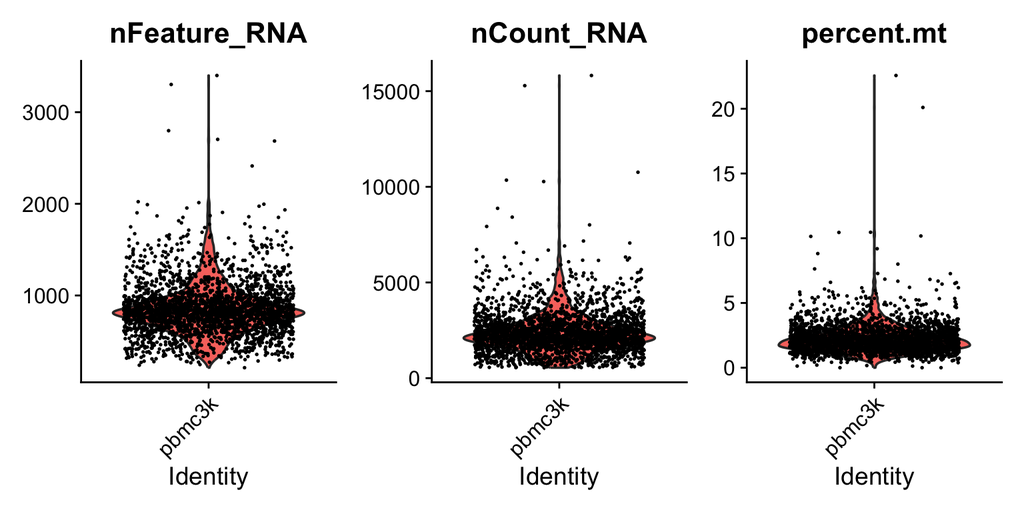

```r
VlnPlot(
  pbmc,
  features = c("nFeature_RNA", "nCount_RNA", "percent.mt"),
  ncol = 3
)
```

## Filter cells, normalize, and find highly variable genes

```r
pbmc <- subset(
  pbmc,
  subset = nFeature_RNA > 200 & nFeature_RNA < 2500 & percent.mt < 5
)

pbmc <- NormalizeData(
  pbmc,
  normalization.method = "LogNormalize",
  scale.factor = 10000
)

pbmc <- FindVariableFeatures(
  pbmc,
  selection.method = "vst",
  nfeatures = 2000
)

hvg_genes <- VariableFeatures(pbmc)

length(hvg_genes)
```

```
## [1] 2000
```

```r
head(hvg_genes, 10)
```

```
##  [1] "PPBP"   "LYZ"    "S100A9" "IGLL5"  "GNLY"   "FTL"    "PF4"    "FTH1"
##  [9] "GNG11"  "S100A8"
```

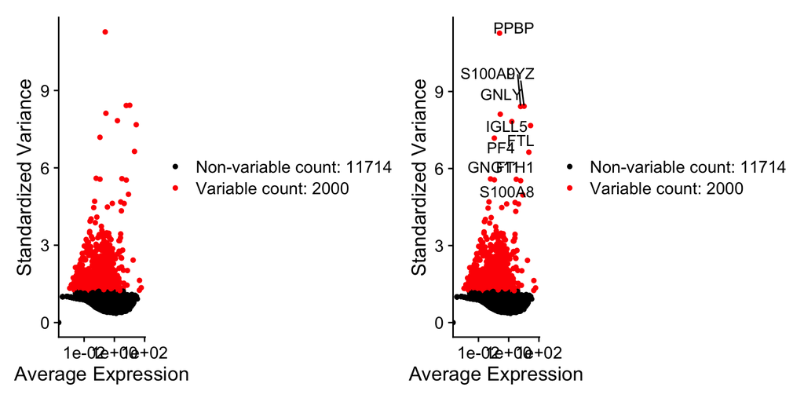

```r
top10 <- head(hvg_genes, 10)
plot1 <- VariableFeaturePlot(pbmc)
plot2 <- LabelPoints(plot = plot1, points = top10, repel = TRUE)
plot1 + plot2
```

# Leave Seurat: extract the matrix for another method

At this point, the Seurat object contains both raw counts and normalized values. The current PBMC tutorial stores:

- raw counts in `pbmc[["RNA"]]$counts`
- normalized values in `pbmc[["RNA"]]$data`
- highly variable genes in `VariableFeatures(pbmc)`

We will extract the normalized expression matrix for the highly variable genes and then make a deliberately simple choice outside Seurat: run `kmeans()` directly on those genes.

```r
dim(pbmc[["RNA"]]$counts)
```

```
## [1] 13714  2638
```

```r
dim(pbmc[["RNA"]]$data)
```

```
## [1] 13714  2638
```

```r
pbmc[["RNA"]]$counts[1:5, 1:5]
```

```
## 5 x 5 sparse Matrix of class "dgCMatrix"
##               AAACATACAACCAC-1 AAACATTGAGCTAC-1 AAACATTGATCAGC-1
## AL627309.1                   .                .                .
## AP006222.2                   .                .                .
## RP11-206L10.2                .                .                .
## RP11-206L10.9                .                .                .
## LINC00115                    .                .                .
##               AAACCGTGCTTCCG-1 AAACCGTGTATGCG-1
## AL627309.1                   .                .
## AP006222.2                   .                .
## RP11-206L10.2                .                .
## RP11-206L10.9                .                .
## LINC00115                    .                .
```

```r
pbmc[["RNA"]]$data[1:5, 1:5]
```

```
## 5 x 5 sparse Matrix of class "dgCMatrix"
##               AAACATACAACCAC-1 AAACATTGAGCTAC-1 AAACATTGATCAGC-1
## AL627309.1                   .                .                .
## AP006222.2                   .                .                .
## RP11-206L10.2                .                .                .
## RP11-206L10.9                .                .                .
## LINC00115                    .                .                .
##               AAACCGTGCTTCCG-1 AAACCGTGTATGCG-1
## AL627309.1                   .                .
## AP006222.2                   .                .
## RP11-206L10.2                .                .
## RP11-206L10.9                .                .
## LINC00115                    .                .
```

```r
hvg_mat <- as.matrix(pbmc[["RNA"]]$data[hvg_genes, ])

dim(hvg_mat)
```

```
## [1] 2000 2638
```

```r
class(hvg_mat)
```

```
## [1] "matrix" "array"
```

```r
stopifnot(length(hvg_genes) > 0)
stopifnot(nrow(hvg_mat) == length(hvg_genes))
stopifnot(ncol(hvg_mat) == ncol(pbmc))
```

`hvg_mat` has genes as rows and cells as columns. The `kmeans()` function expects observations in rows, so we transpose the matrix before clustering.

```r
cell_hvg_mat <- t(hvg_mat)

dim(cell_hvg_mat)
```

```
## [1] 2638 2000
```

```r
stopifnot(nrow(cell_hvg_mat) == ncol(pbmc))
stopifnot(ncol(cell_hvg_mat) == length(hvg_genes))
```

# Perform clustering outside Seurat

This is not meant to be the best clustering strategy. We are using it because it is easy to understand and because it shows how to leave the Seurat workflow, try something in base R, and then return to Seurat for visualization. Here we run `kmeans()` directly on a high-dimensional matrix of highly variable genes.

```r
set.seed(1234)

km_res <- kmeans(
  x = cell_hvg_mat,
  centers = 5,
  nstart = 20
)

str(km_res, max.level = 1)
```

```
## List of 9
##  $ cluster     : Named int [1:2638] 3 4 3 2 1 3 3 3 3 2 ...
##   ..- attr(*, "names")= chr [1:2638] "AAACATACAACCAC-1" "AAACATTGAGCTAC-1" "AAACATTGATCAGC-1" "AAACCGTGCTTCCG-1" ...
##  $ centers     : num [1:5, 1:2000] 0.0246 0.1065 0.0788 0.0285 0.1053 ...
##   ..- attr(*, "dimnames")=List of 2
##  $ totss       : num 1421163
##  $ withinss    : num [1:5] 183293 111165 561575 154635 197264
##  $ tot.withinss: num 1207933
##  $ betweenss   : num 213230
##  $ size        : int [1:5] 329 252 1291 345 421
##  $ iter        : int 3
##  $ ifault      : int 0
##  - attr(*, "class")= chr "kmeans"
```

```r
head(km_res$cluster)
```

```
## AAACATACAACCAC-1 AAACATTGAGCTAC-1 AAACATTGATCAGC-1 AAACCGTGCTTCCG-1
##                3                4                3                2
## AAACCGTGTATGCG-1 AAACGCACTGGTAC-1
##                1                3
```

```r
table(km_res$cluster)
```

```
##
##    1    2    3    4    5
##  329  252 1291  345  421
```

`km_res` is an ordinary R object returned by `kmeans()`, not a Seurat object.

# Return to Seurat

Now we add the k-means cluster labels back into Seurat metadata and use Seurat to build a UMAP for plotting.

```r
pbmc$kmeans_cluster <- factor(km_res$cluster)

dplyr::count(pbmc[[]], kmeans_cluster, sort = TRUE)
```

```
##   kmeans_cluster    n
## 1              3 1291
## 2              5  421
## 3              4  345
## 4              1  329
## 5              2  252
```

```r
set.seed(1234)

pbmc <- ScaleData(pbmc, features = hvg_genes, verbose = FALSE)
pbmc <- RunPCA(pbmc, features = hvg_genes, verbose = FALSE)
pbmc <- RunUMAP(pbmc, reduction = "pca", dims = 1:10, verbose = FALSE)
```

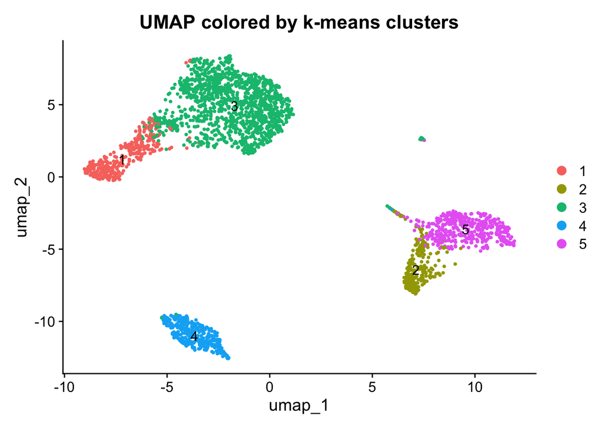

```r
DimPlot(pbmc, group.by = "kmeans_cluster", label = TRUE) +
  ggplot2::ggtitle("UMAP colored by k-means clusters")
```

# Your turn

This notebook stops before the “best” clustering method on purpose. Use it as a starting point and answer these questions on your own:

1. What changes when you increase or decrease the number of k-means clusters?
2. Why might direct k-means on the highly variable gene matrix be a poor choice for scRNA-seq data?
3. If you wanted to improve this analysis while still leaving Seurat, what would you try next?